# 09 popravci podataka

```python
import pandas as pd
import matplotlib.pyplot as plt
import seaborn as sns
from sklearn.preprocessing import LabelEncoder
```

```python
popis = pd.read_excel ("Allianz2_kolone.xlsx")
```

## Cilj ovog zadatka je uspostaviti konzistentnost među podacima. Želimo nazive stupaca u istom formatu, provjeriti ima li duplikata i riješiti ih, popraviti greške u unosu itd.

```python
popis.head()
```

|  | City | GeNdeR_oF_CustoMer | Age | InCoMe | ILLness |
| --- | --- | --- | --- | --- | --- |
| 0 | Dallas | Male | 41.0 | 40367.0 | No |
| 1 | Dallas | Male | 54.0 | 45084.0 | No |
| 2 | Dallas | male | 42.0 | 52483.0 | No |
| 3 | Dallas | Male | 40.0 | 40941.0 | No |
| 4 | Dallas | male | 46.0 | 50289.0 | No |

```python
popis.describe()
```

|  | Age | InCoMe |
| --- | --- | --- |
| count | 149998.000000 | 149998.000000 |
| mean | 44.950126 | 91253.196076 |
| std | 11.572513 | 24989.427742 |
| min | 25.000000 | -654.000000 |
| 25% | 35.000000 | 80868.000000 |
| 50% | 45.000000 | 93655.000000 |
| 75% | 55.000000 | 104519.000000 |
| max | 65.000000 | 177157.000000 |

```python
popis.info()
```

```
<class 'pandas.core.frame.DataFrame'>
RangeIndex: 150000 entries, 0 to 149999
Data columns (total 5 columns):
 #   Column              Non-Null Count   Dtype
---  ------              --------------   -----
 0   City                149998 non-null  object
 1   GeNdeR_oF_CustoMer  149998 non-null  object
 2   Age                 149998 non-null  float64
 3   InCoMe              149998 non-null  float64
 4   ILLness             150000 non-null  object
dtypes: float64(2), object(3)
memory usage: 5.7+ MB
```

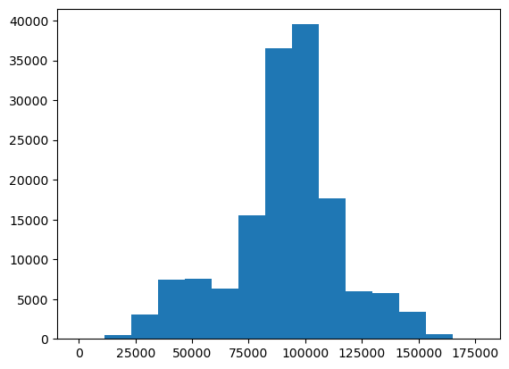

```python
plt.hist (popis.InCoMe, bins = 15)
```

## Pregledom podataka ustvrdili smo da postoji jedna negativna vrijednost. Na sreću, imamo eksperta iz domene pri ruci koji nam je rekao da je došlo do greške i da se radi o vrijednosti 6540. Ručno ćemo promijeniti vrijednost stupca korisštenjem naredbe replace

```python
popis.sort_values (by = ["InCoMe"])
```

|  | City | GeNdeR_oF_CustoMer | Age | InCoMe | ILLness |
| --- | --- | --- | --- | --- | --- |
| 245 | Dallas | Female | 40.0 | -654.0 | Yes |
| 7896 | Dallas | Female | 34.0 | 584.0 | No |
| 18484 | Dallas | Female | 43.0 | 2474.0 | No |
| 9298 | Dallas | Female | 31.0 | 2667.0 | Yes |
| 17135 | Dallas | Female | 39.0 | 3842.0 | No |
| ... | ... | ... | ... | ... | ... |
| 109060 | Mountain View | Male | 61.0 | 173991.0 | No |
| 105281 | Mountain View | Male | 41.0 | 176746.0 | No |
| 109350 | Mountain View | Male | 58.0 | 177157.0 | No |
| 116 | Dallas | Male | 48.0 | NaN | Yes |
| 120 | NaN | NaN | NaN | NaN | Yes |

150000 rows × 5 columns

```python
popis["InCoMe"].replace({-654.0: 6540.0}, inplace=True)
```

```python
popis.describe()
```

|  | Age | InCoMe |
| --- | --- | --- |
| count | 149998.000000 | 149998.000000 |
| mean | 44.950126 | 91253.244037 |
| std | 11.572513 | 24989.258252 |
| min | 25.000000 | 584.000000 |
| 25% | 35.000000 | 80868.000000 |
| 50% | 45.000000 | 93655.000000 |
| 75% | 55.000000 | 104519.000000 |
| max | 65.000000 | 177157.000000 |

# Duplikati - jako opasna stvar!!!!

```python
popis.duplicated().sum()
```

```
668
```

## U našem datasetu imamo 668 duplih upisa. Bilo bi lijepo maknuti ih jer njihovo postojanje definitivno će utjecati na buduće analize.

```python
popis.drop_duplicates(inplace=True)
```

```python
popis.describe()
```

|  | Age | InCoMe |
| --- | --- | --- |
| count | 149330.000000 | 149330.000000 |
| mean | 44.947405 | 91241.575986 |
| std | 11.573796 | 25010.768465 |
| min | 25.000000 | 584.000000 |
| 25% | 35.000000 | 80834.000000 |
| 50% | 45.000000 | 93641.500000 |
| 75% | 55.000000 | 104527.000000 |
| max | 65.000000 | 177157.000000 |

```python
isna_values = popis[popis.isna().any(axis=1)]
```

```python
isna_values
```

|  | City | GeNdeR_oF_CustoMer | Age | InCoMe | ILLness |
| --- | --- | --- | --- | --- | --- |
| 107 | NaN | Male | 47.0 | 30382.0 | No |
| 112 | Dallas | NaN | 39.0 | 53649.0 | No |
| 114 | Dallas | Male | NaN | 46788.0 | Yes |
| 116 | Dallas | Male | 48.0 | NaN | Yes |
| 120 | NaN | NaN | NaN | NaN | Yes |

## Za micanje duplicata koristimo naredbu drop_duplicates(). Parametar inplace koristimo kako bi zaista prihvatio naredbu, a ne pomislio da se radi samo o upitu.

```python
popis.rename(columns = {'GeNdeR_oF_CustoMer':'Gender'}, inplace = True)
```

```python
popis.head()
```

|  | City | Gender | Age | InCoMe | ILLness |
| --- | --- | --- | --- | --- | --- |
| 0 | Dallas | Male | 41.0 | 40367.0 | No |
| 1 | Dallas | Male | 54.0 | 45084.0 | No |
| 2 | Dallas | male | 42.0 | 52483.0 | No |
| 3 | Dallas | Male | 40.0 | 40941.0 | No |
| 4 | Dallas | male | 46.0 | 50289.0 | No |

## Python je zabavan programski jezik, ne smijemo zaboraviti kako je case sensitive. Pregledom vrijednosti za varijablu gender, vidimo da imamo dva različita načina pisanja spola Male / male

```python
popis.Gender.value_counts()
```

```
Gender
Male      83389
Female    65939
male          2
Name: count, dtype: int64
```

```python
popis["Gender"]=popis["Gender"].str.title()
```

```python
popis.Gender.value_counts()
```

```
Gender
Male      83391
Female    65939
Name: count, dtype: int64
```

```python
popis.info()
```

```
<class 'pandas.core.frame.DataFrame'>
Index: 149332 entries, 0 to 149999
Data columns (total 5 columns):
 #   Column   Non-Null Count   Dtype
---  ------   --------------   -----
 0   City     149330 non-null  object
 1   Gender   149330 non-null  object
 2   Age      149330 non-null  float64
 3   InCoMe   149330 non-null  float64
 4   ILLness  149332 non-null  object
dtypes: float64(2), object(3)
memory usage: 6.8+ MB
```

## U našem radu možemo odrediti koje varijable su nam ključne

## Kad radimo s kategoričkim varijablama, preporuka je da se kategoričke varijable koje su nam ključne pretvore u numeričke

### Postoje neki tree based algritmi koji podnose kategoričke podatke, ali zbog konzistentnosti se preporuča pretvaranje u numeričke

### Također, i neuronske mreže trebaju tranformaciju podataka u numeričke podatke

## Primjetite na vrhu da smo na početku uvezli Labelencoder koji nam služi za transformaciju podataka

```python
label_encoder = LabelEncoder()
```

### Inicijalizacija label encodera

```python
popis['Gender_Label'] = label_encoder.fit_transform(popis['Gender'])
```

```python
popis.head(25)
```

|  | City | Gender | Age | InCoMe | ILLness | Gender_Label |
| --- | --- | --- | --- | --- | --- | --- |
| 0 | Dallas | Male | 41.0 | 40367.0 | No | 1 |
| 1 | Dallas | Male | 54.0 | 45084.0 | No | 1 |
| 2 | Dallas | Male | 42.0 | 52483.0 | No | 1 |
| 3 | Dallas | Male | 40.0 | 40941.0 | No | 1 |
| 4 | Dallas | Male | 46.0 | 50289.0 | No | 1 |
| 5 | Dallas | Female | 36.0 | 50786.0 | No | 0 |
| 6 | Dallas | Female | 32.0 | 33155.0 | No | 0 |
| 7 | Dallas | Male | 39.0 | 30914.0 | No | 1 |
| 8 | Dallas | Male | 51.0 | 68667.0 | No | 1 |
| 9 | Dallas | Female | 30.0 | 50082.0 | No | 0 |
| 10 | Dallas | Female | 48.0 | 41524.0 | Yes | 0 |
| 11 | Dallas | Male | 47.0 | 54777.0 | No | 1 |
| 12 | Dallas | Male | 46.0 | 62749.0 | No | 1 |
| 13 | Dallas | Female | 42.0 | 50894.0 | No | 0 |
| 14 | Dallas | Female | 61.0 | 38429.0 | No | 0 |
| 15 | Dallas | Male | 43.0 | 34074.0 | No | 1 |
| 16 | Dallas | Male | 27.0 | 50398.0 | No | 1 |
| 17 | Dallas | Male | 38.0 | 46373.0 | Yes | 1 |
| 18 | Dallas | Male | 47.0 | 51137.0 | No | 1 |
| 19 | Dallas | Female | 35.0 | 23688.0 | No | 0 |
| 20 | Dallas | Male | 57.0 | 17378.0 | No | 1 |
| 21 | Dallas | Male | 33.0 | 45919.0 | No | 1 |
| 22 | Dallas | Female | 33.0 | 23001.0 | No | 0 |
| 23 | Dallas | Female | 27.0 | 34292.0 | Yes | 0 |
| 24 | Dallas | Male | 58.0 | 55190.0 | No | 1 |

## Ova metoda se zove 'Label encoding', koristi se za ordinalne podatke gdje bismo mogli primjetiti redoslijed (malo / srednje / veliko ili ljeto / jesen / zima / proljeće)

# U datasetu postoje neki missing values... popraviti!